# Linear Models

January 29, 2018

## Note

We’ll use the cdc dataset a little longer. As we model this, be sure to try it with the dataset (porche) used in the book

## Linear Models (1.1)

## Notation

\[Data = Model + Error\] \[Y = f(X) + \epsilon\] \[Y = \mu_Y + \epsilon\] \[\mu_Y = f(X) = \beta_0+\beta_1 X\] \[Y = \beta_0 + \beta_1 X + \epsilon\]

## Making a plot

We’ll use the `ggplot2` package (can also use “base” graphics), use `require(ggplot2)` and load `cdc` dataset.

## Making a quick plot

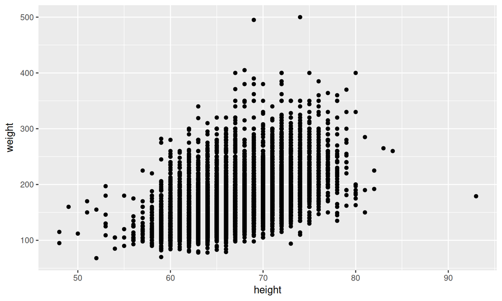

```r
qplot(height, weight, data=cdc)
```

## Adding a best-fit line

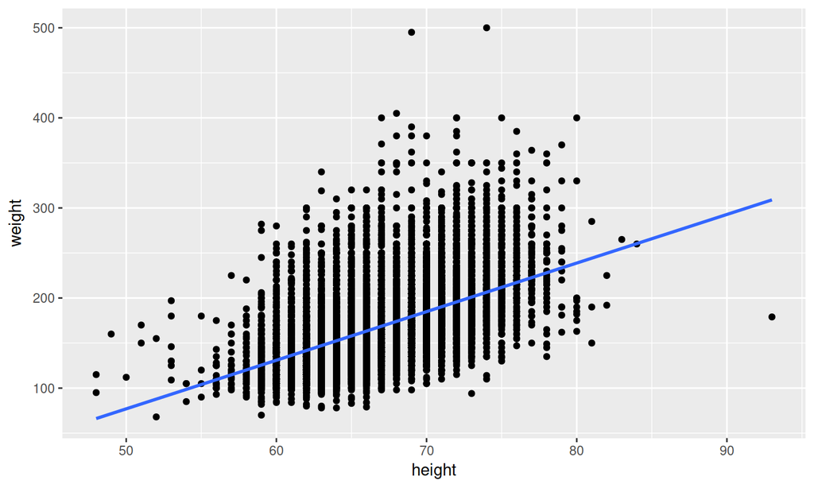

```r
qplot(height, weight, data=cdc)+geom_smooth(method="lm", se=FALSE)
```

## Method of finding best fit line

- SSE - sum of squares of the error
- least sqaures line

## Getting the equation for that line

```r
lm(weight~height, data=cdc)
```

```
##
## Call:
## lm(formula = weight ~ height, data = cdc)
##
## Coefficients:
## (Intercept)       height
##    -192.742        5.395
```

## More Info

```r
summary(lm(weight~height, data=cdc))
```

```
##
## Call:
## lm(formula = weight ~ height, data = cdc)
##
## Residuals:
##      Min       1Q   Median       3Q      Max
## -129.956  -22.512   -5.275   16.304  315.515
##
## Coefficients:
##               Estimate Std. Error t value Pr(>|t|)
## (Intercept) -192.74158    3.84529  -50.12   <2e-16 ***
## height         5.39459    0.05713   94.43   <2e-16 ***
## ---
## Signif. codes:  0 '***' 0.001 '**' 0.01 '*' 0.05 '.' 0.1 ' ' 1
##
## Residual standard error: 33.33 on 19998 degrees of freedom
## Multiple R-squared:  0.3084, Adjusted R-squared:  0.3083
## F-statistic:  8917 on 1 and 19998 DF,  p-value: < 2.2e-16
```

What’s the equation of the best-fitting line? What do the values mean?

## dplyr

Of course - there’s a dplyr way to do this with pipes (if you like them)

```r
cdc %>% lm(weight~height, data=.) %>% summary()
```

```
##
## Call:
## lm(formula = weight ~ height, data = .)
##
## Residuals:
##      Min       1Q   Median       3Q      Max
## -129.956  -22.512   -5.275   16.304  315.515
##
## Coefficients:
##               Estimate Std. Error t value Pr(>|t|)
## (Intercept) -192.74158    3.84529  -50.12   <2e-16 ***
## height         5.39459    0.05713   94.43   <2e-16 ***
## ---
## Signif. codes:  0 '***' 0.001 '**' 0.01 '*' 0.05 '.' 0.1 ' ' 1
##
## Residual standard error: 33.33 on 19998 degrees of freedom
## Multiple R-squared:  0.3084, Adjusted R-squared:  0.3083
## F-statistic:  8917 on 1 and 19998 DF,  p-value: < 2.2e-16
```

## What Residuals Mean

\[y_i = \beta_0 + \beta_1 x_i + \epsilon_i\] \[weight_i = \beta_0 + \beta_1 * height_i + \epsilon\] \[\widehat{weight} = \beta_0 + \beta_1* height\]

## Residuals

```r
mod1 <- lm(weight~height, data=cdc)
mod1$residuals
```

[output not shown]

[output cut: 7945 more lines]

[output not shown]

## Summarize residuals

```r
summary(mod1$residuals)
```

```
##     Min.  1st Qu.   Median     Mean  3rd Qu.     Max.
## -129.956  -22.512   -5.275    0.000   16.304  315.515
```

## Plot residuals

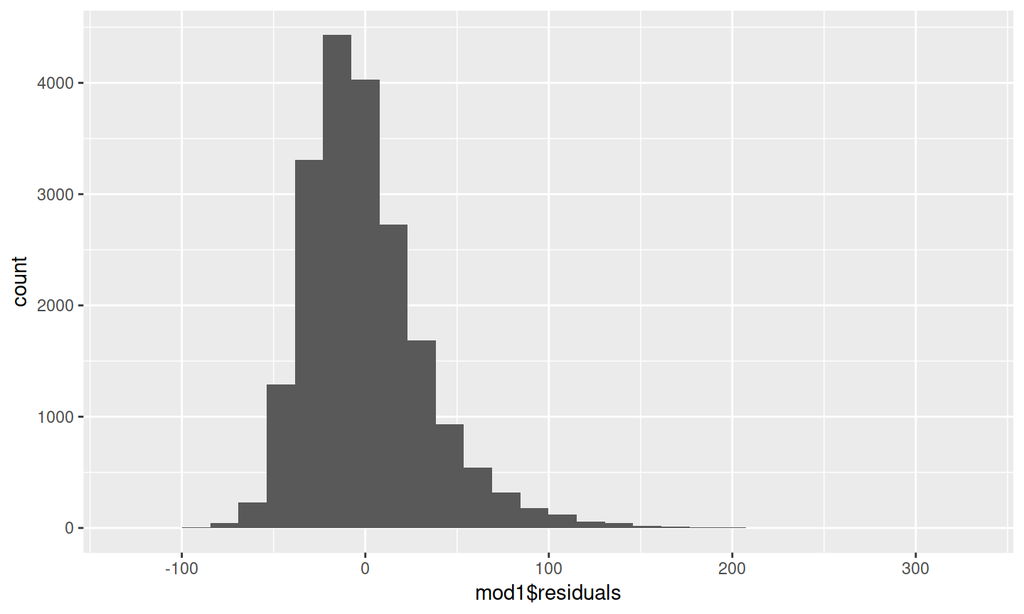

```r
qplot(mod1$residuals)
```

## Conditions for Linear Models (1.2)

## Conditions

“We hope that the residuals are small and contain no pattern that could be exploited to better explain the response variable.”

## Linearity

“The overall relationship between the variables has a linear pattern. The average values of the response Y for each value of X fall on a common straight line.”

(Plot them)

## Zero Mean (of residuals)

“The error distribution is centered at zero. This means that the points are scattered at random above and below the line. (Note: By using least squares regression, we force the residual mean to be zero. Other techniques would not necessarily satisfy this condition.)”

## Constant Variance (homoscedasticity)

“The variability in the errors is the same for all values of the predictor variable. This means that the spread of points around the line remains fairly constant.”

## Testing constant variance

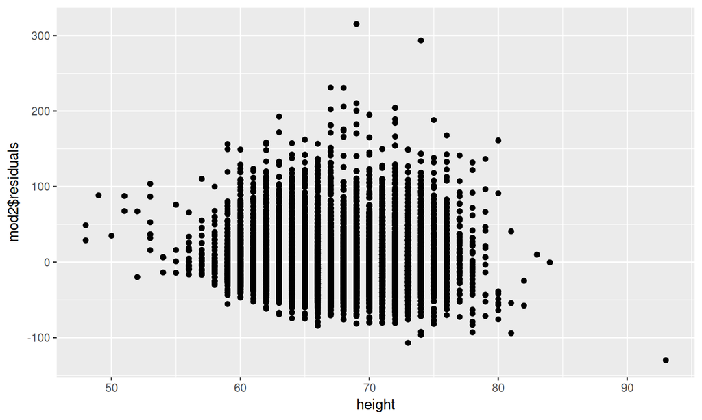

```r
mod2 <- lm(weight~height, data=cdc)
qplot(height, mod2$residuals, data=cdc)
```

## Another example

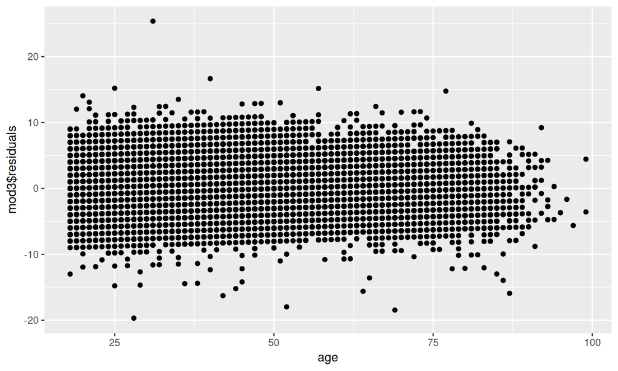

```r
mod3 <- lm(height~age, data=cdc)
qplot(age,mod3$residuals, data=cdc)
```

## Independence

“The errors are assumed to be independent from one another. Thus, one point falling above or below the line has no influence on the location of another point.”

## Inference Assumptions

“When we are interested in using the model to make formal inferences (conducting hypothesis tests or providing confidence intervals), additional assumptions are needed.”

## Random

“The data are obtained using a random process. Most commonly, this arises either from random sampling from a population of interest or from the use of randomization in a statistical experiment.”

## Normality

“In order to use standard distributions for confidence intervals and hypothesis tests, we often need to assume that the random errors follow a normal distribution.”

## Testing normality

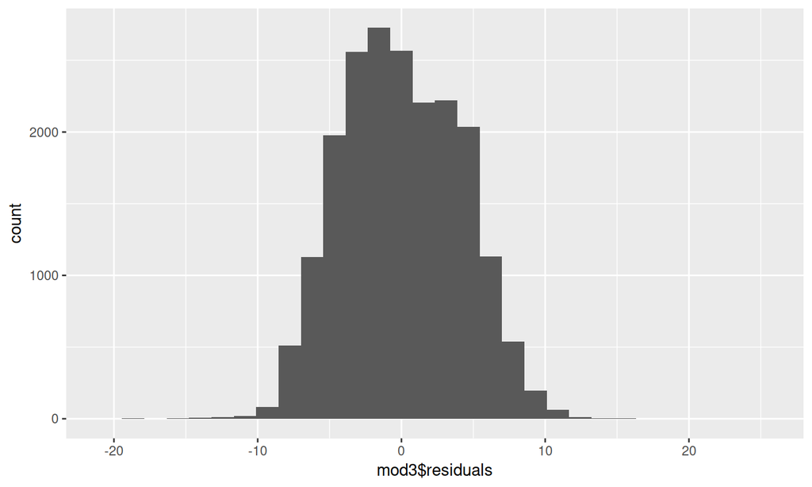

```r
qplot(mod3$residuals)
```

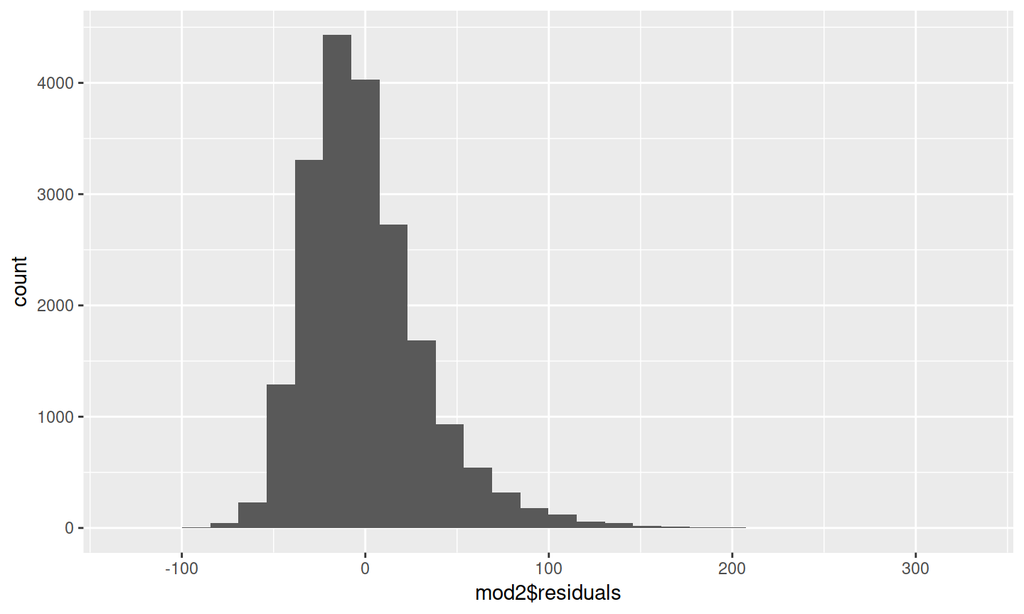

```r
qplot(mod2$residuals)
```

## Standard Errors with a toy dataset

```r
mtcars
```

```
##                      mpg cyl  disp  hp drat    wt  qsec vs am gear carb
## Mazda RX4           21.0   6 160.0 110 3.90 2.620 16.46  0  1    4    4
## Mazda RX4 Wag       21.0   6 160.0 110 3.90 2.875 17.02  0  1    4    4
## Datsun 710          22.8   4 108.0  93 3.85 2.320 18.61  1  1    4    1
## Hornet 4 Drive      21.4   6 258.0 110 3.08 3.215 19.44  1  0    3    1
## Hornet Sportabout   18.7   8 360.0 175 3.15 3.440 17.02  0  0    3    2
## Valiant             18.1   6 225.0 105 2.76 3.460 20.22  1  0    3    1
## Duster 360          14.3   8 360.0 245 3.21 3.570 15.84  0  0    3    4
## Merc 240D           24.4   4 146.7  62 3.69 3.190 20.00  1  0    4    2
## Merc 230            22.8   4 140.8  95 3.92 3.150 22.90  1  0    4    2
## Merc 280            19.2   6 167.6 123 3.92 3.440 18.30  1  0    4    4
## Merc 280C           17.8   6 167.6 123 3.92 3.440 18.90  1  0    4    4
## Merc 450SE          16.4   8 275.8 180 3.07 4.070 17.40  0  0    3    3
## Merc 450SL          17.3   8 275.8 180 3.07 3.730 17.60  0  0    3    3
## Merc 450SLC         15.2   8 275.8 180 3.07 3.780 18.00  0  0    3    3
## Cadillac Fleetwood  10.4   8 472.0 205 2.93 5.250 17.98  0  0    3    4
## Lincoln Continental 10.4   8 460.0 215 3.00 5.424 17.82  0  0    3    4
## Chrysler Imperial   14.7   8 440.0 230 3.23 5.345 17.42  0  0    3    4
## Fiat 128            32.4   4  78.7  66 4.08 2.200 19.47  1  1    4    1
## Honda Civic         30.4   4  75.7  52 4.93 1.615 18.52  1  1    4    2
## Toyota Corolla      33.9   4  71.1  65 4.22 1.835 19.90  1  1    4    1
## Toyota Corona       21.5   4 120.1  97 3.70 2.465 20.01  1  0    3    1
## Dodge Challenger    15.5   8 318.0 150 2.76 3.520 16.87  0  0    3    2
## AMC Javelin         15.2   8 304.0 150 3.15 3.435 17.30  0  0    3    2
## Camaro Z28          13.3   8 350.0 245 3.73 3.840 15.41  0  0    3    4
## Pontiac Firebird    19.2   8 400.0 175 3.08 3.845 17.05  0  0    3    2
## Fiat X1-9           27.3   4  79.0  66 4.08 1.935 18.90  1  1    4    1
## Porsche 914-2       26.0   4 120.3  91 4.43 2.140 16.70  0  1    5    2
## Lotus Europa        30.4   4  95.1 113 3.77 1.513 16.90  1  1    5    2
## Ford Pantera L      15.8   8 351.0 264 4.22 3.170 14.50  0  1    5    4
## Ferrari Dino        19.7   6 145.0 175 3.62 2.770 15.50  0  1    5    6
## Maserati Bora       15.0   8 301.0 335 3.54 3.570 14.60  0  1    5    8
## Volvo 142E          21.4   4 121.0 109 4.11 2.780 18.60  1  1    4    2
```

## Regression standard error

Standard deviation of the error term

\[\widehat{\sigma_\epsilon} = \sqrt{\frac{SSE}{n-2}}\]

```r
mtcars %>% lm(mpg~wt, data=.) %>% summary()
```

```
##
## Call:
## lm(formula = mpg ~ wt, data = .)
##
## Residuals:
##     Min      1Q  Median      3Q     Max
## -4.5432 -2.3647 -0.1252  1.4096  6.8727
##
## Coefficients:
##             Estimate Std. Error t value Pr(>|t|)
## (Intercept)  37.2851     1.8776  19.858  < 2e-16 ***
## wt           -5.3445     0.5591  -9.559 1.29e-10 ***
## ---
## Signif. codes:  0 '***' 0.001 '**' 0.01 '*' 0.05 '.' 0.1 ' ' 1
##
## Residual standard error: 3.046 on 30 degrees of freedom
## Multiple R-squared:  0.7528, Adjusted R-squared:  0.7446
## F-statistic: 91.38 on 1 and 30 DF,  p-value: 1.294e-10
```

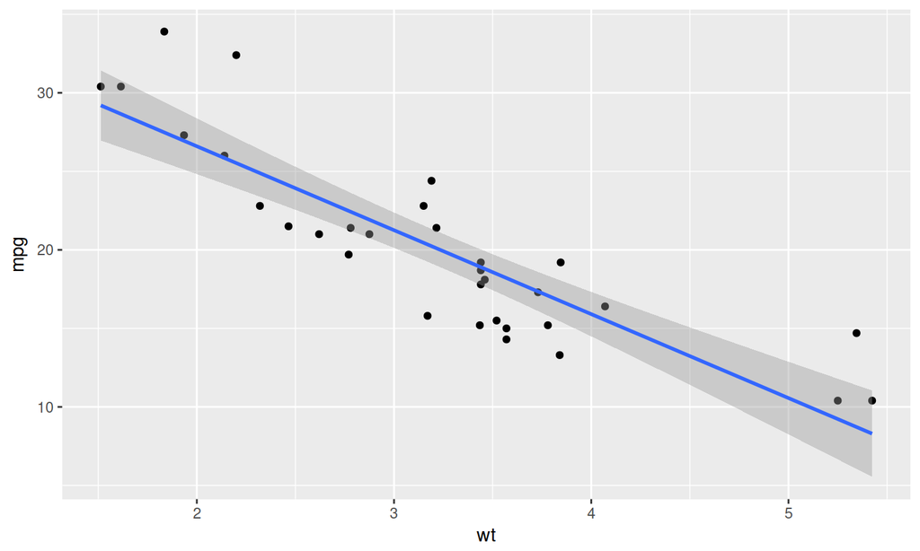

```r
qplot(wt, mpg, data=mtcars) +
    geom_smooth(method="lm")
```

## Where we are

- Github
- Pick your own dataset: lab 0
- RMarkdown

## Assumptions

- Assumptions vs conditions

Not standard, but I consider: * Randomly collected data - assumption * Homoscedasticity or normality - condition

## Assessing Conditions (1.3)

## Residuals vs fits

- We already looked at residuals vs predictor
- Now we look at residual vs predicted
- The book has some nice graphs of what these can look like, we’ll generate some

## Example

Reminder:

```r
summary(mod2)
```

```
##
## Call:
## lm(formula = weight ~ height, data = cdc)
##
## Residuals:
##      Min       1Q   Median       3Q      Max
## -129.956  -22.512   -5.275   16.304  315.515
##
## Coefficients:
##               Estimate Std. Error t value Pr(>|t|)
## (Intercept) -192.74158    3.84529  -50.12   <2e-16 ***
## height         5.39459    0.05713   94.43   <2e-16 ***
## ---
## Signif. codes:  0 '***' 0.001 '**' 0.01 '*' 0.05 '.' 0.1 ' ' 1
##
## Residual standard error: 33.33 on 19998 degrees of freedom
## Multiple R-squared:  0.3084, Adjusted R-squared:  0.3083
## F-statistic:  8917 on 1 and 19998 DF,  p-value: < 2.2e-16
```

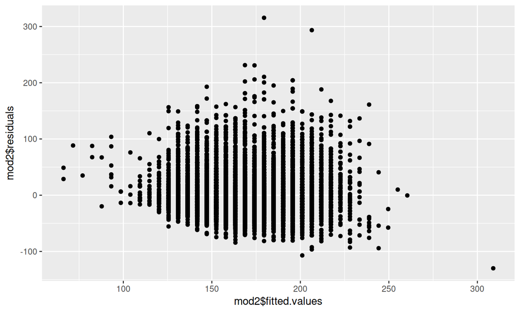

```r
qplot(mod2$fitted.values, mod2$residuals)
```

## Making up some data

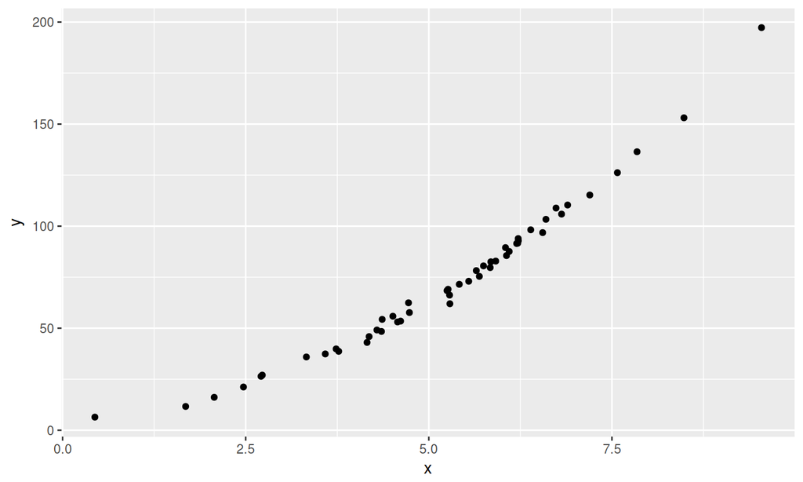

```r
x <- rnorm(50,5,2)
noise <- rnorm(50,0,3)
y <- 2*x^2+4+x+3+noise
qplot(x,y)
```

## Running a lm

```r
randmod <- lm(y~x)
summary(randmod)
```

```
##
## Call:
## lm(formula = y ~ x)
##
## Residuals:
##     Min      1Q  Median      3Q     Max
## -12.389  -5.054  -2.180   1.937  35.190
##
## Coefficients:
##             Estimate Std. Error t value Pr(>|t|)
## (Intercept) -34.6487     3.9741  -8.719 1.85e-11 ***
## x            20.6158     0.7218  28.563  < 2e-16 ***
## ---
## Signif. codes:  0 '***' 0.001 '**' 0.01 '*' 0.05 '.' 0.1 ' ' 1
##
## Residual standard error: 8.805 on 48 degrees of freedom
## Multiple R-squared:  0.9444, Adjusted R-squared:  0.9433
## F-statistic: 815.9 on 1 and 48 DF,  p-value: < 2.2e-16
```

## Assessing the fit

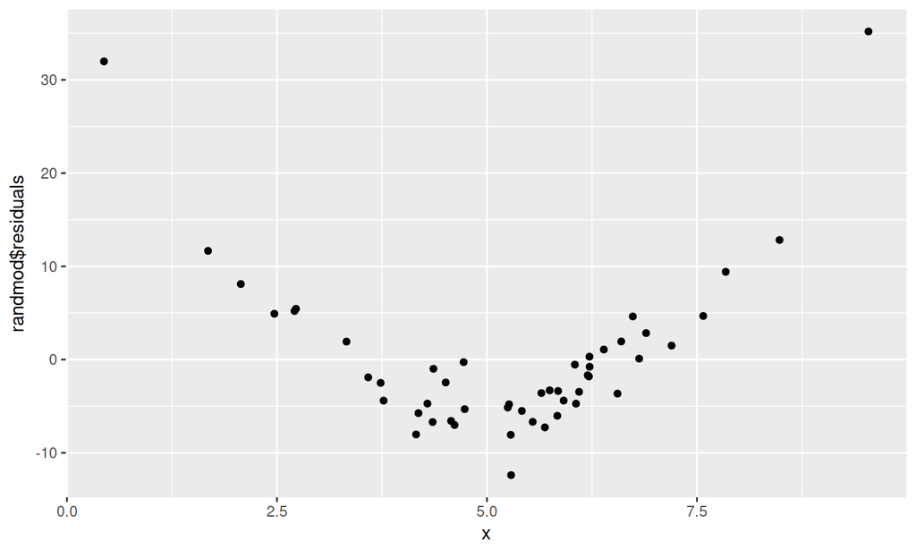

```r
qplot(x,randmod$residuals)
```

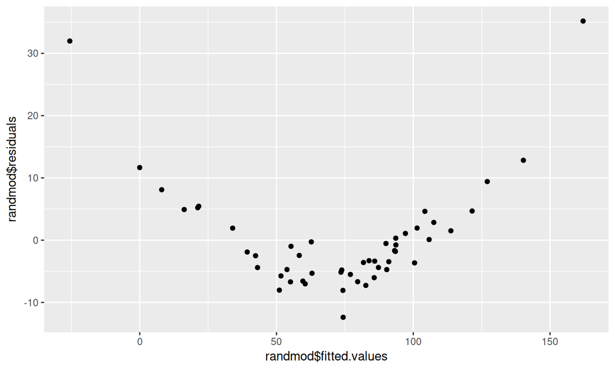

```r
qplot(randmod$fitted.values, randmod$residuals)
```

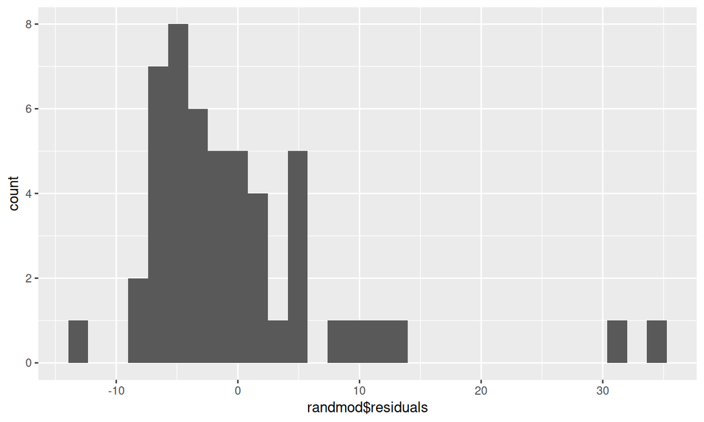

```r
qplot(randmod$residuals)
```

## qqplots (normal plot)

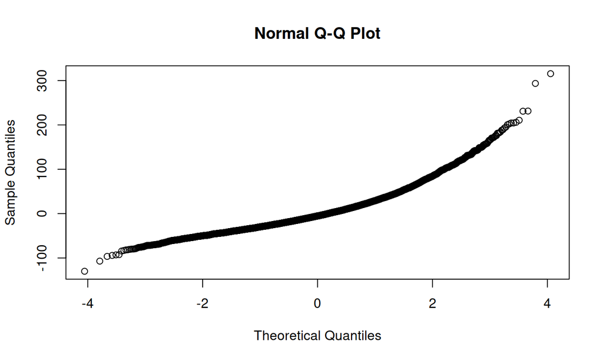

```r
qqnorm(mod2$residuals)
```

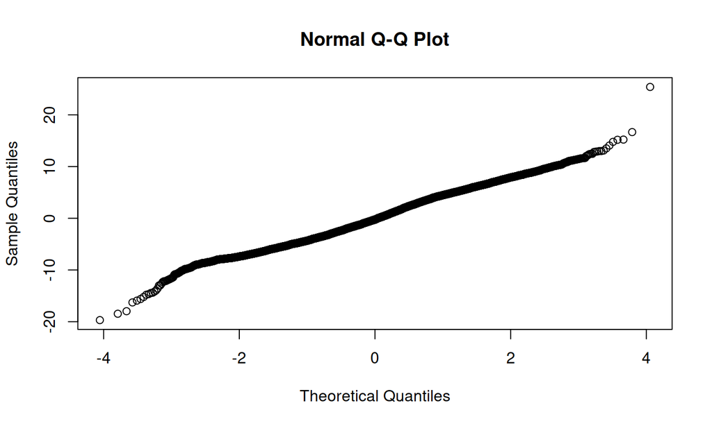

```r
qqnorm(mod3$residuals)
```

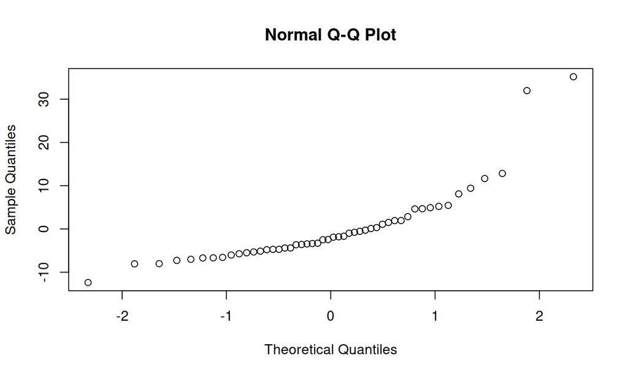

```r
qqnorm(randmod$residuals)
```

## Perfect qqnorm plot

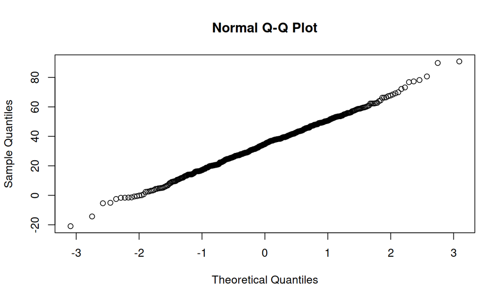

```r
normaldata <- rnorm(500,34,17)
qqnorm(normaldata)
```

## Model assessment

- Linearity
- Zero mean
- Constant variance
- Independent and random
- Normality

## Model use: Making predictions

```r
summary(mod3)
```

```
##
## Call:
## lm(formula = height ~ age, data = cdc)
##
## Residuals:
##     Min      1Q  Median      3Q     Max
## -19.696  -3.125  -0.245   3.146  25.395
##
## Coefficients:
##              Estimate Std. Error t value Pr(>|t|)
## (Intercept) 68.536818   0.081214  843.91   <2e-16 ***
## age         -0.030042   0.001684  -17.84   <2e-16 ***
## ---
## Signif. codes:  0 '***' 0.001 '**' 0.01 '*' 0.05 '.' 0.1 ' ' 1
##
## Residual standard error: 4.094 on 19998 degrees of freedom
## Multiple R-squared:  0.01567,    Adjusted R-squared:  0.01562
## F-statistic: 318.4 on 1 and 19998 DF,  p-value: < 2.2e-16
```

Suppose age is 27:

```r
new <- data.frame(age=c(27, 28, 29))
predict.lm(mod3, new)
```

```
##        1        2        3
## 67.72570 67.69566 67.66561
```

## Note

Recommended datacamp (not required) course: Correlation and Regression

## Transformations (1.4)

## What to do when the lm assumptions/conditions aren’t satisfied?

- In particular, normality of residuals and/or constant variance of residuals
- Can also be useful if we can “see” that the relationship is not linear

## The usual tools

- Transform one or the other variable using:
  - Square
  - Square root
  - Inverse
  - log (log in R is ln)

## Example Dataset

```r
wordrecall <- read.delim("~/Dropbox/teaching/246/data/wordrecall.txt")
wordrecall <- tbl_df(wordrecall)
wordrecall
```

```
## # A tibble: 13 x 2
##     time   prop
##    <int>  <dbl>
##  1     1 0.840
##  2     5 0.710
##  3    15 0.610
##  4    30 0.560
##  5    60 0.540
##  6   120 0.470
##  7   240 0.450
##  8   480 0.380
##  9   720 0.360
## 10  1440 0.260
## 11  2880 0.200
## 12  5760 0.160
## 13 10080 0.0800
```

## Model

```r
wordmodel <- lm(prop ~ time, data=wordrecall)
summary(wordmodel)
```

```
##
## Call:
## lm(formula = prop ~ time, data = wordrecall)
##
## Residuals:
##      Min       1Q   Median       3Q      Max
## -0.18564 -0.11913 -0.04495  0.08496  0.31418
##
## Coefficients:
##               Estimate Std. Error t value Pr(>|t|)
## (Intercept)  5.259e-01  4.881e-02  10.774 3.49e-07 ***
## time        -5.571e-05  1.457e-05  -3.825  0.00282 **
## ---
## Signif. codes:  0 '***' 0.001 '**' 0.01 '*' 0.05 '.' 0.1 ' ' 1
##
## Residual standard error: 0.1523 on 11 degrees of freedom
## Multiple R-squared:  0.5709, Adjusted R-squared:  0.5318
## F-statistic: 14.63 on 1 and 11 DF,  p-value: 0.002817
```

## Graphs

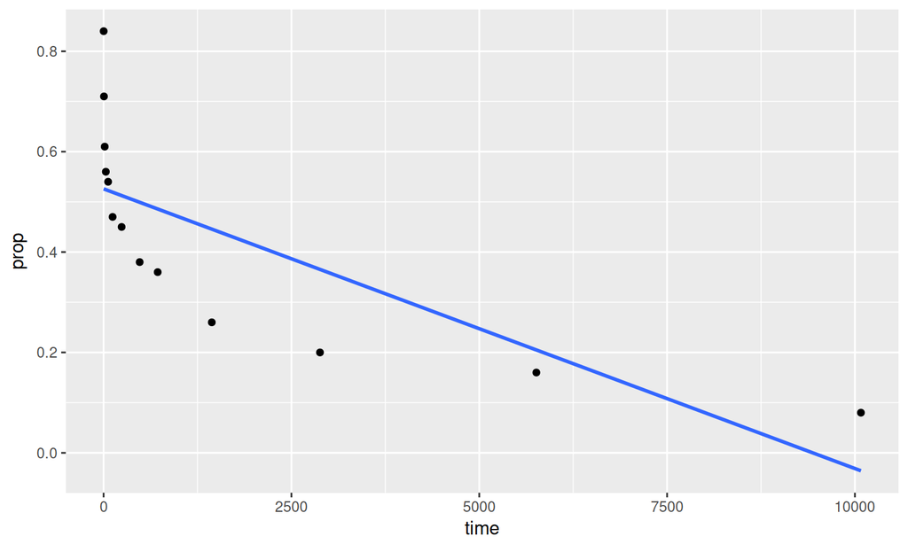

```r
wordrecall %>% qplot(time, prop, data=.)+geom_smooth(method="lm", se=F)
```

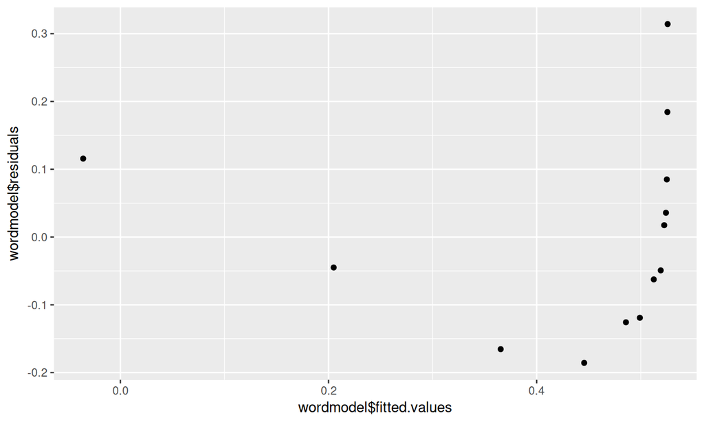

```r
qplot(wordmodel$fitted.values, wordmodel$residuals)
```

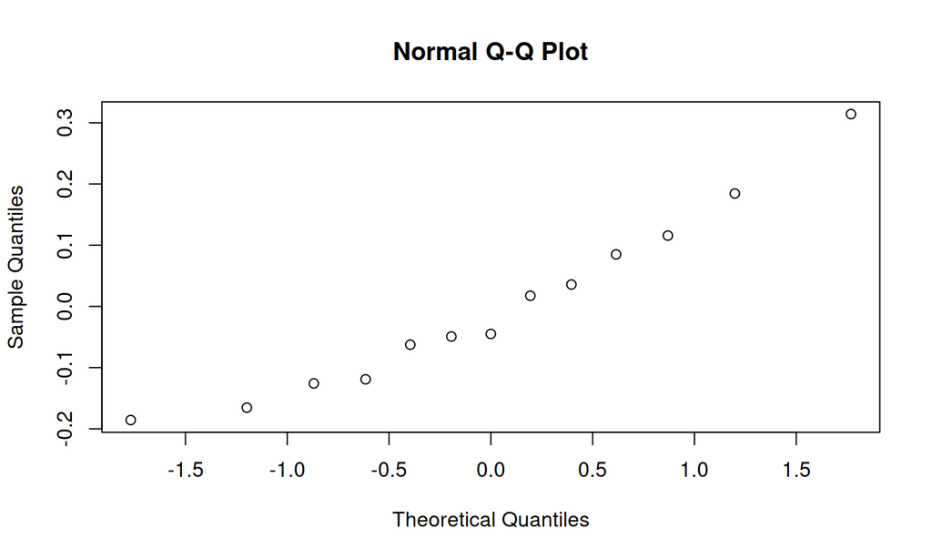

```r
qqnorm(wordmodel$residuals)
```

## How do we fix this?

- Transform the variables
- Use mutate() to construct new variables which might work better, e.g.: log of prop, log of time, prop^-1.25, etc.
- What works well?

```r
wordrecall <- wordrecall %>% mutate(logprop = log(prop))
wordrecall
```

```
## # A tibble: 13 x 3
##     time   prop logprop
##    <int>  <dbl>   <dbl>
##  1     1 0.840   -0.174
##  2     5 0.710   -0.342
##  3    15 0.610   -0.494
##  4    30 0.560   -0.580
##  5    60 0.540   -0.616
##  6   120 0.470   -0.755
##  7   240 0.450   -0.799
##  8   480 0.380   -0.968
##  9   720 0.360   -1.02
## 10  1440 0.260   -1.35
## 11  2880 0.200   -1.61
## 12  5760 0.160   -1.83
## 13 10080 0.0800  -2.53
```

## Using our best model, let’s make some prediction

Pick a time. What is the expected proportion of words recalled at that time?

## Note

Taking the square root of y is not the same as a quadratic regression. What’s the difference?

## 1.5 Outliers and where to find them

## Terms

- Standardized residuals: make residuals into z-scores
- Studentized (deleted-t) residuals: remove outliers to find std error, then determine residual

## Reminder

```r
summary(wordmodel)
```

```
##
## Call:
## lm(formula = prop ~ time, data = wordrecall)
##
## Residuals:
##      Min       1Q   Median       3Q      Max
## -0.18564 -0.11913 -0.04495  0.08496  0.31418
##
## Coefficients:
##               Estimate Std. Error t value Pr(>|t|)
## (Intercept)  5.259e-01  4.881e-02  10.774 3.49e-07 ***
## time        -5.571e-05  1.457e-05  -3.825  0.00282 **
## ---
## Signif. codes:  0 '***' 0.001 '**' 0.01 '*' 0.05 '.' 0.1 ' ' 1
##
## Residual standard error: 0.1523 on 11 degrees of freedom
## Multiple R-squared:  0.5709, Adjusted R-squared:  0.5318
## F-statistic: 14.63 on 1 and 11 DF,  p-value: 0.002817
```

```r
stdres <- rstandard(wordmodel)
stdres
```

```
##          1          2          3          4          5          6
##  2.1780115  1.2782768  0.5888613  0.2480608  0.1210047 -0.3402912
##          7          8          9         10         11         12
## -0.4316200 -0.8200766 -0.8634613 -1.2691793 -1.1387176 -0.3362319
##         13
##  1.4427129
```

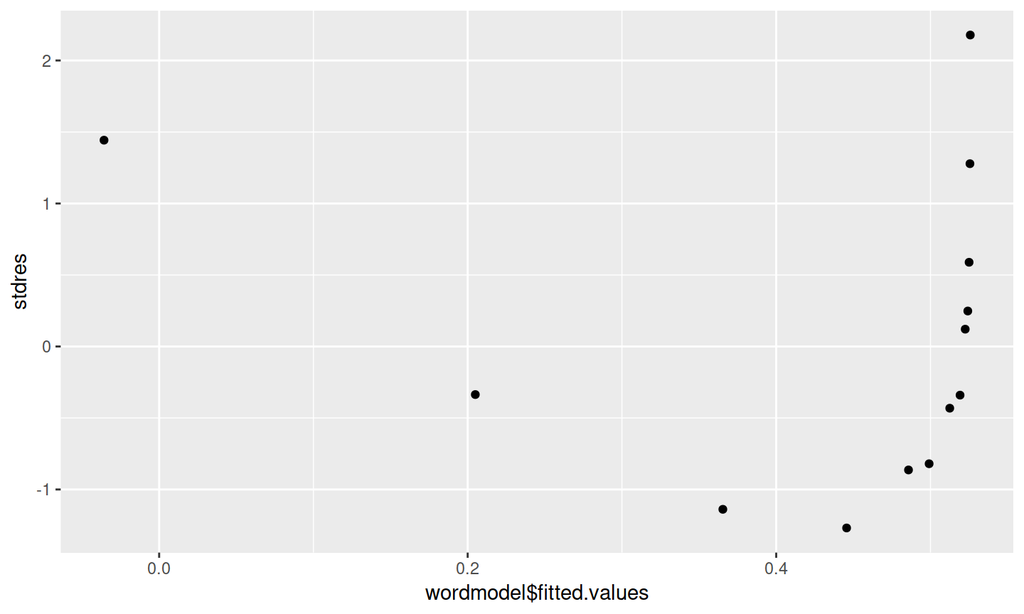

```r
qplot(wordmodel$fitted.values, stdres)
```

```r
studres <- rstudent(wordmodel)
studres
```

```
##          1          2          3          4          5          6
##  2.7536109  1.3208322  0.5705216  0.2371810  0.1154504 -0.3261763
##          7          8          9         10         11         12
## -0.4150633 -0.8069700 -0.8526818 -1.3098122 -1.1559946 -0.3222448
##         13
##  1.5276789
```

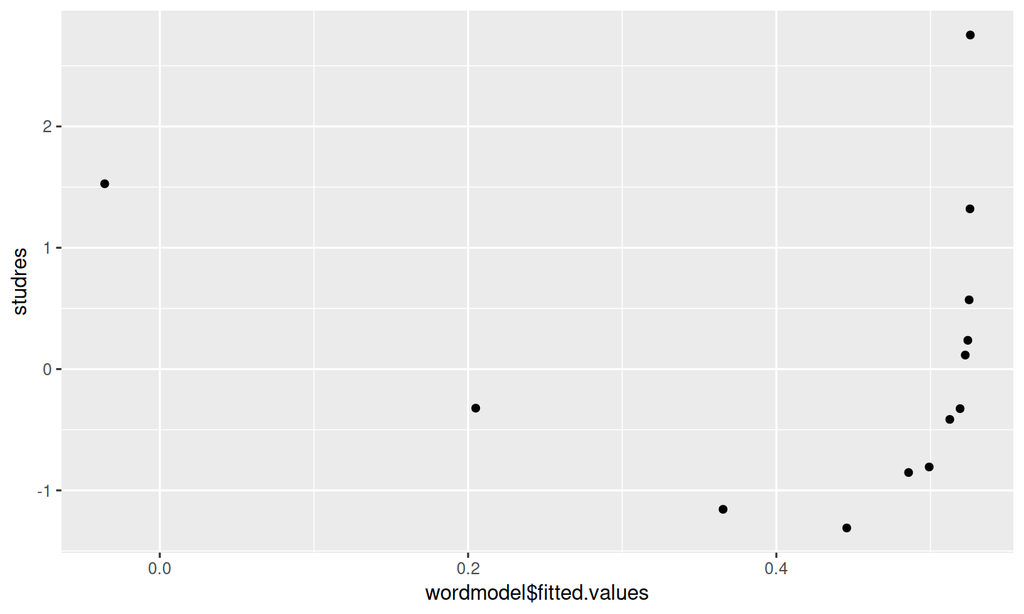

```r
qplot(wordmodel$fitted.values, studres)
```

## Another example

- The PalmBeach dataset is an excellent example. I’ll also show that we don’t have to download the data to our computer first:

```r
library(readr)
PalmBeach <- read_csv("http://stat2.org/datasets/PalmBeach.csv")
```

(Note there are also rda files on the stat2 website!)

How can we recreate the analysis with and without the outlier in R?

## Terms

- influence: how well the point aligns to the trend
- leverage: how far the point (\(x\)) is from the mean of the predictors (\(\bar{x}\))